# Leadership: Second (midsemester)

Irina Benedyk

2026-05-21

# Second (Mid-semester) Leadership Competency Analysis

“Engineering leadership consists of capabilities and values that transform technical people from individual contributors into those who can lead teams to deliver a complex multi-disciplinary product” © Gordon-MIT Engineering Leadership Program.

**Cohort:** Civil Engineering student, mostly juniors, *Spring 2026*.

**Course:** Introduction into Transportation System Analysis (for most students this course is the first exposure to the transportation engineering).

This is an analysis of the data for second leadership survey from 103 respondents, collected in the middle of the course (before Spring break) to establish impacts of weekly group activities (5 out of 6 were finished by the time of the data collection) and to obtain a baseline before the project activities (starting after the spring break).

Before the education begins, students generally feel most confident in collaborative tasks and least confident in formal leadership and innovation-specific roles. Let’s see how they feel in the middle of the course.

[Link to the initial survey responses analysis](https://birina-tech.github.io/CIE439_Spring_2026_Leadership_1/)

## Methodology

This study evaluates leadership competencies among engineering students (mostly juniors) via self-assessment. The evaluation is based on a modified framework by Stevens et al. (2021) and adopts Huckabee’s (2023) definition of leadership: the ability to influence others to reach a specific goal.

**Survey Instrument (exactly the same as the first survey)**

Participants were asked to respond to the following prompt:

“Indicate how well your previous education prepared you for your professional career and enhanced your ability relative to each of the following skills using a 5-point Likert scale: (1) Poorly, (2) Fairly, (3) Neither poorly nor well, (4) Very Well, and (5) Excellently.”

**Evaluated Leadership Dimensions**

- **Leading Teams:** Running meetings and adjusting to personality types.
- **Strategic Thinking:** Using mission and vision statements effectively.
- **Teamwork:** Contributing to high-performing teams.
- **Project Management:** Applying formal processes to technical projects.
- **Feedback:** Mastering the art of professional critique.
- **Self-Reflection:** Ongoing evaluation of leadership growth.
- **Ethical Practice:** Navigating ethical issues and decision-making.
- **Innovation:** Fostering creative team cultures.
- **Global Competencies:** Navigating cross-cultural environments and reducing bias.
- **Emotional Intelligence:** Managing conflict and emotional regulation.
- **Communication:** Tailoring professional writing and speaking to audiences.
- **Initiative:** Taking ownership of new challenges and responsibilities.

“Stevens, J. D., Lang, D., Handley, M., Park, J. J., & Mittan, P. (2021). Evaluating the Effectiveness of an Undergraduate Engineering Leadership Development Minor on Graduates. ASEE Annual Conference and Exposition, Conference Proceedings.”

## Average Scores

A bar chart below depicts averages for each metrics.

Highest Baseline: In the first leasdership survey students rate themselves highest in Teamwork ($4.08$) and Effective Communication ($4.07$). This time, students rated themselves higher then $4.08$ on 5 different metrics, with significant change in the teamwork (highly trained skill using weekly group activities).

Lowest Baseline: The lowest average is still the same, with some growth as perceived by students, Leading Teams is the lowest with average $3.76$ ( was $3.55$) and Innovation Culture with the average $3.84$ (was $3.60$).

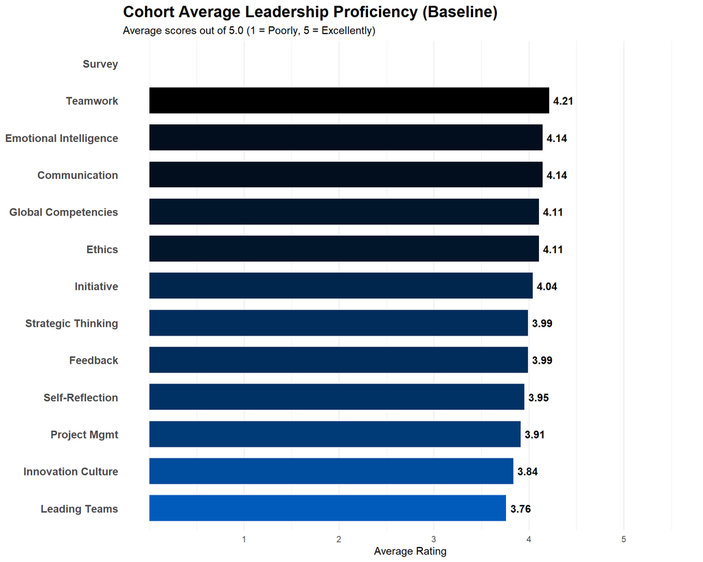

## Distribution of Ratings

A stacked bar chart shows the “spread” or distribution of abilities. An average score of $3.5$ can result from everyone being “Neutral,” or from half the group being “Excellent” and the other half being “Poor.”

In the second iteration of the survey, the frequency of $1$ and $2$ ratings decreased across all metrics, but to varying degrees. The three worts metrics showing the largest frequencies of $1$ and $2$ are as follows: Innovation Culture ranks first (similar to the first survey), but the second and third places are occupied by new competencies, namely Leading Teams and Teamwork. This presents an interesting dynamic: despite having the highest average score overall, Teamwork ranks third in the frequencies of $1$ and $2$ ratings.

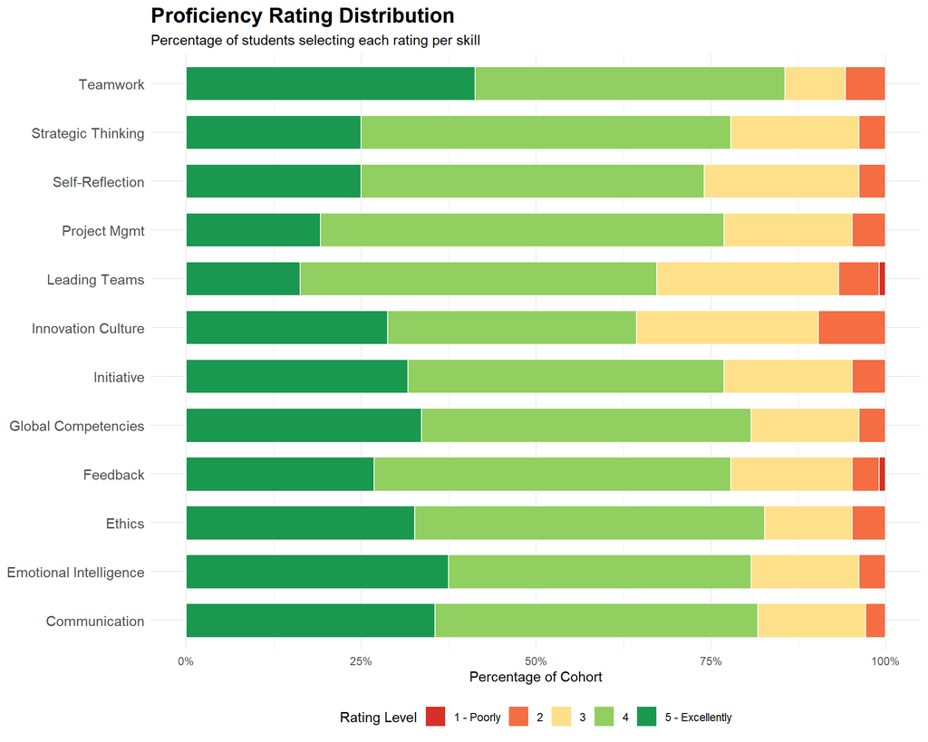

## Correlation: How Skills Move Together

A heat map reveals which skills are naturally linked in students’ minds.

**High correlations**

Global Competencies & Innovation Culture ($0.57$). The strong link between global awareness and innovation reinforces the well-documented business principle that diversity drives creativity. Employees who possess strong global competencies are likely more exposed to different markets, diverse viewpoints, and alternative ways of working.

**Low correlations**

Global Competencies and Leading Teams ($0.17$). While Global Competencies align strongly with broader, cultural traits like Ethics and Innovation, the remarkably low correlation with Leading Teams reveals a crucial distinction between perceived strategic awareness and operational management. This weak relationship suggests that proficiency in one area does not naturally translate to the other.

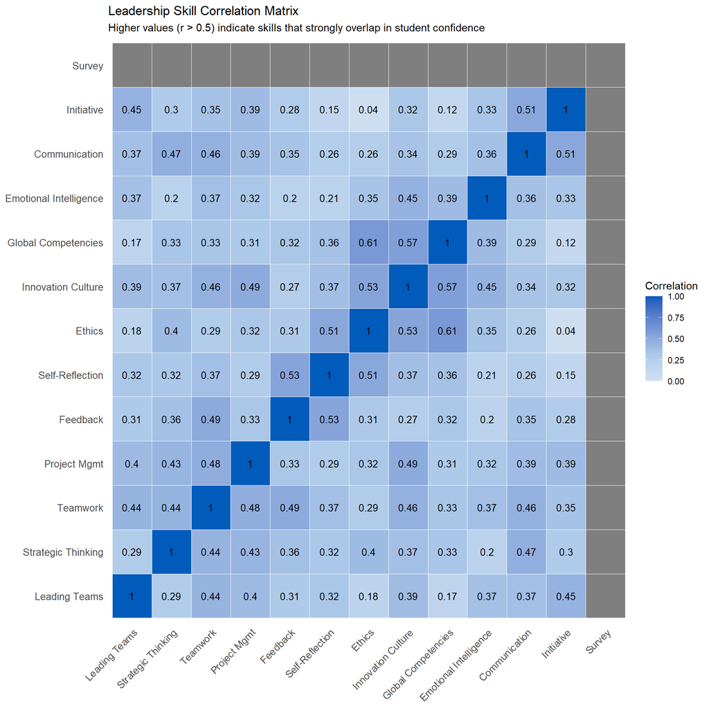

## Growth Analysis: Initial vs. Mid-Semester (Interaction Effect)

To evaluate whether the weekly group activities had a statistically significant impact on students’ self-perceived leadership competencies, we compared the distributions of the Initial baseline survey with this Mid-semester survey.

**Understanding the Results:** A *p*-value of less than $0.10 / 0.05 / 0.01$ (marked with an asterisk `*`, `**`, or `***`) indicates that the difference in scores between the beginning and the middle of the semester is statistically significant at different level of confidence, meaning the growth is highly likely due to the educational activities rather than random chance.

[figure not shown]